# Graphic and Table Examples

Clifton Bell

2024-08-09

This file contains examples of graphics and tables to support the Catawba River reservoir water quality evaluation. I’m sharing to give Tom and Bill a flavor of what we have to work with, which is quite a bit actually. Formatting of these plots can be adjusted as needed, and stations and parameters can easily be swapped out.

I have not written any interpretation yet although a few things do pop out. Overall I conclude that Lake Wateree shows the most signals of potential eutrophication-related use impacts such as high pH, high cyanobacteria, T&O in drinking water, etc. Upon coming back from vacation I plan on starting to write interpretative report sections around these plots.

## Chlorophyll-a Boxplots

These plots help characterize the existing chla conditions in the reservoirs. They only use growing season data from the upper meter of the water column. Only stations with 5 or more data are used. The stations are plotted from upstream to downstream.

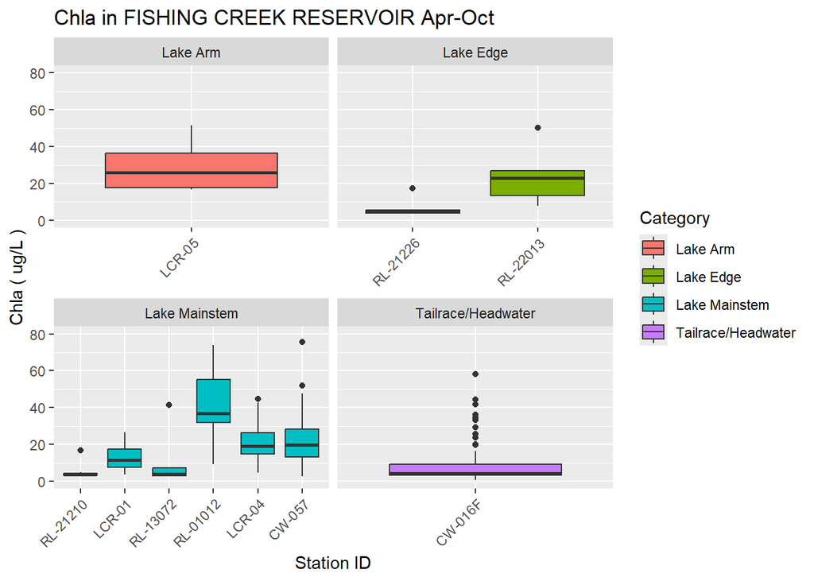

Figure X - Spatial pattern in chl-a in Fishing Creek Reservoir.

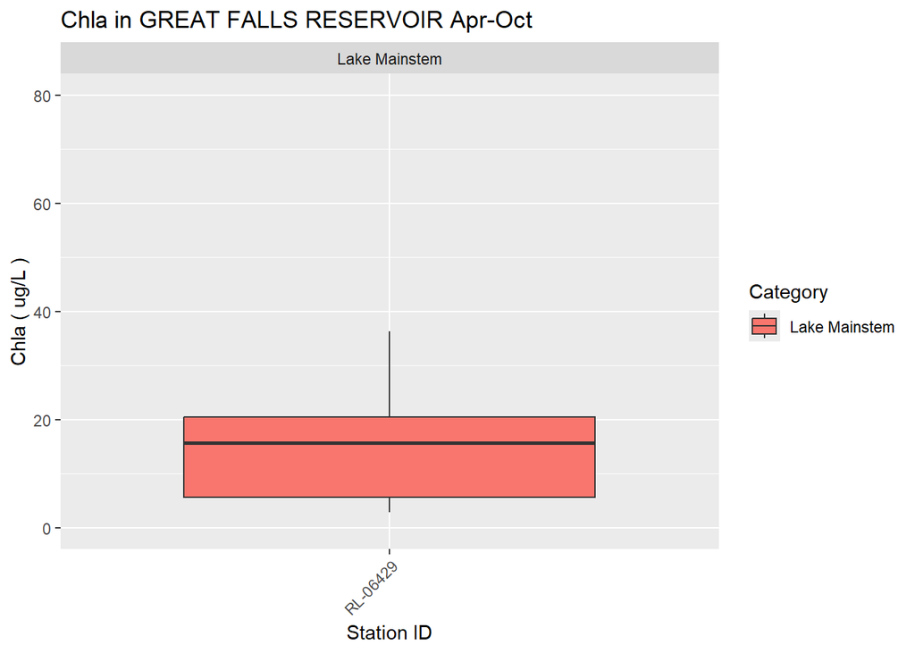

Figure X - Chl-a in Great Falls Reservoir.

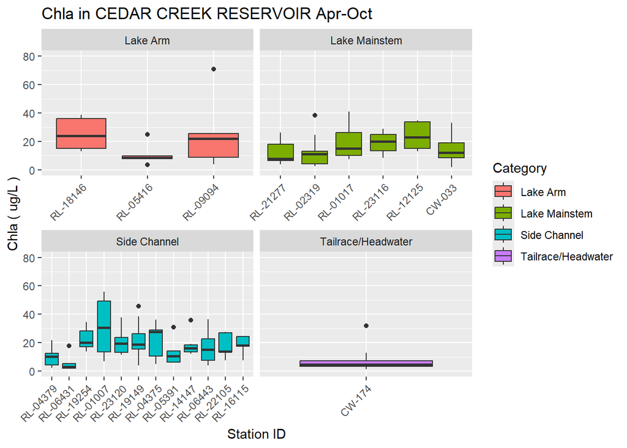

Figure X - Spatial pattern in chl-a in Cedar Creek Reservoir.

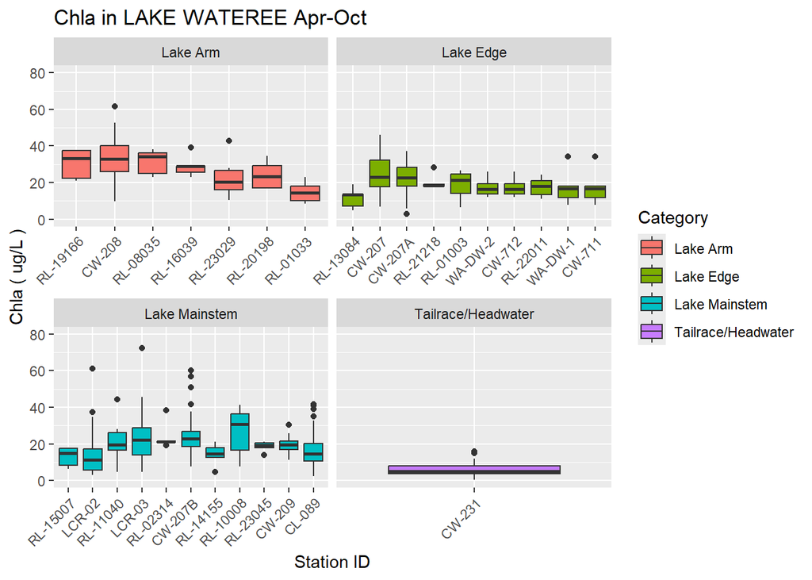

Figure X - Spatial pattern in chl-a in Lake Wateree.

## Chlorophyll Time Series Plots

These plots would be used to infer trends in chla. Major trends are not apparent in the charts. If there is more interest in trends we could perform a seasonal Kendall trend test on selected stations.

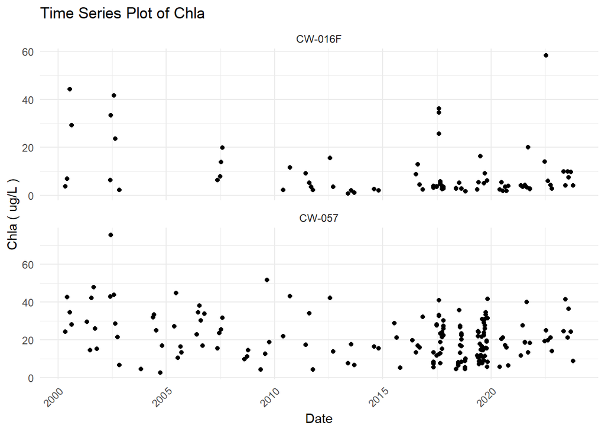

Figure X - Chl-a over time at Fishing Creek Reservoir stations.

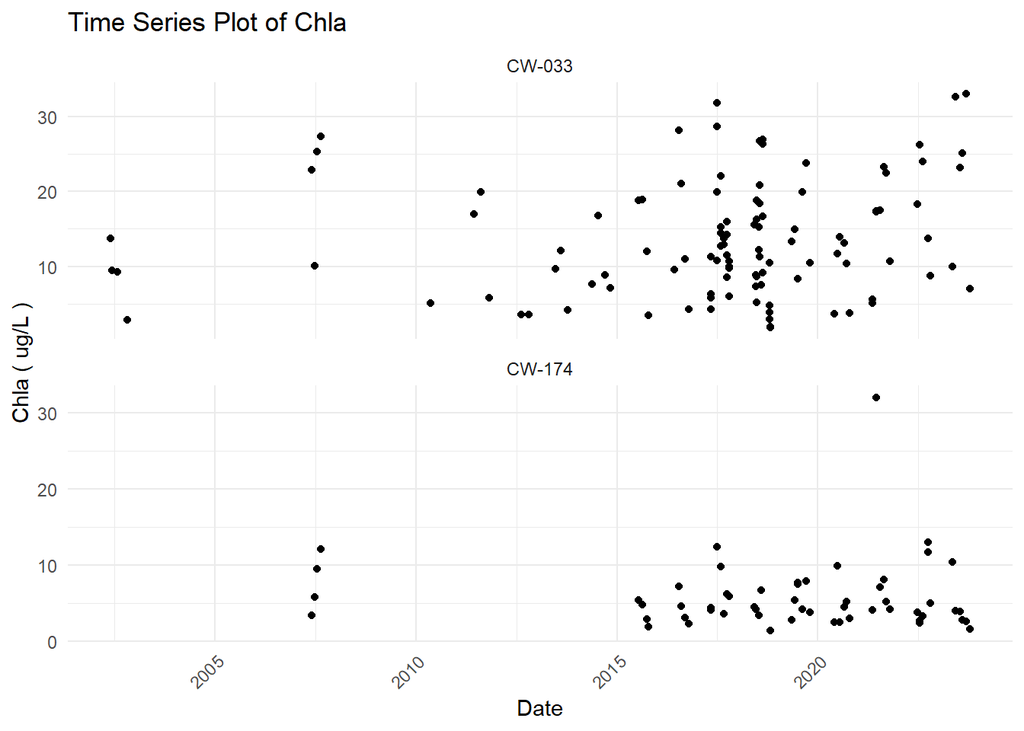

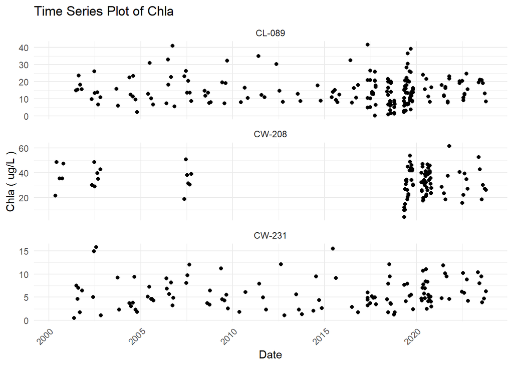

## Seasonal Plots for Chlorophyll-a, DO, and pH

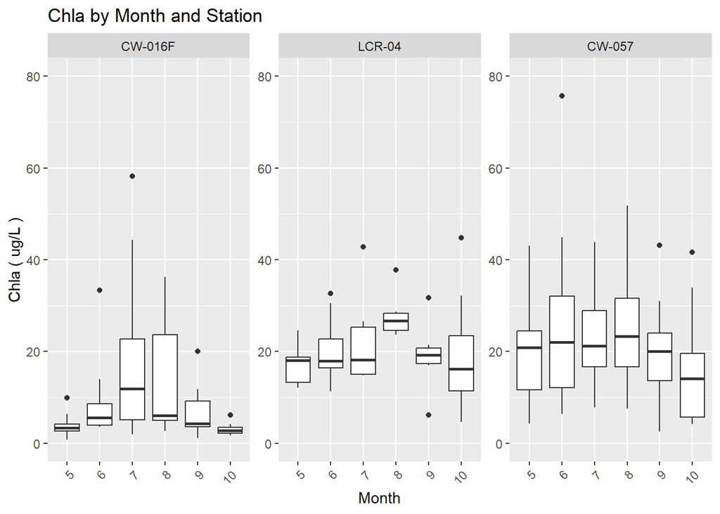

Figure X - Seasonal pattern in chl-a at Fishing Creek Reservoir stations.

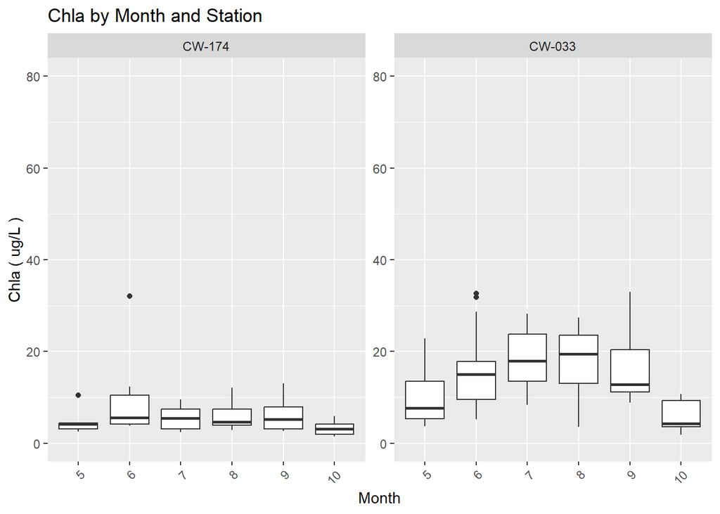

Figure X - Seasonal pattern in chl-a at Cedar Creek Reservoir stations.

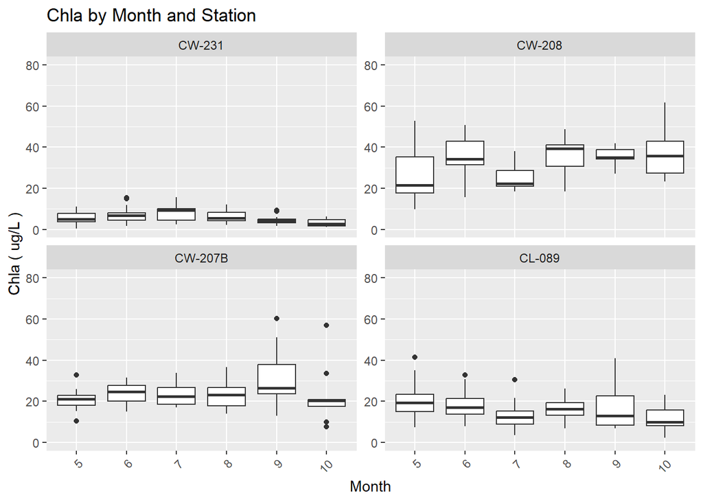

Figure X - Seasonal pattern in chl-a at Lake Wateree Reservoir stations.

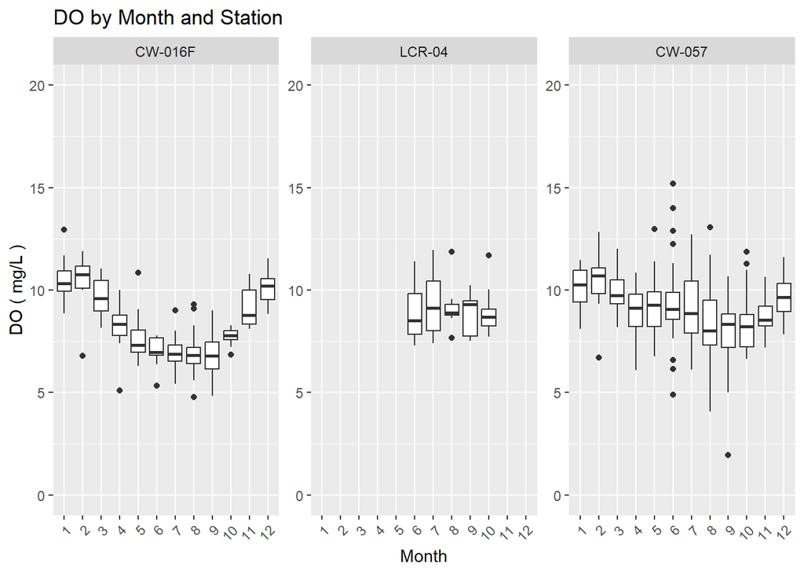

Figure X - Seasonal pattern in DO at Fishing Creek Reservoir stations.

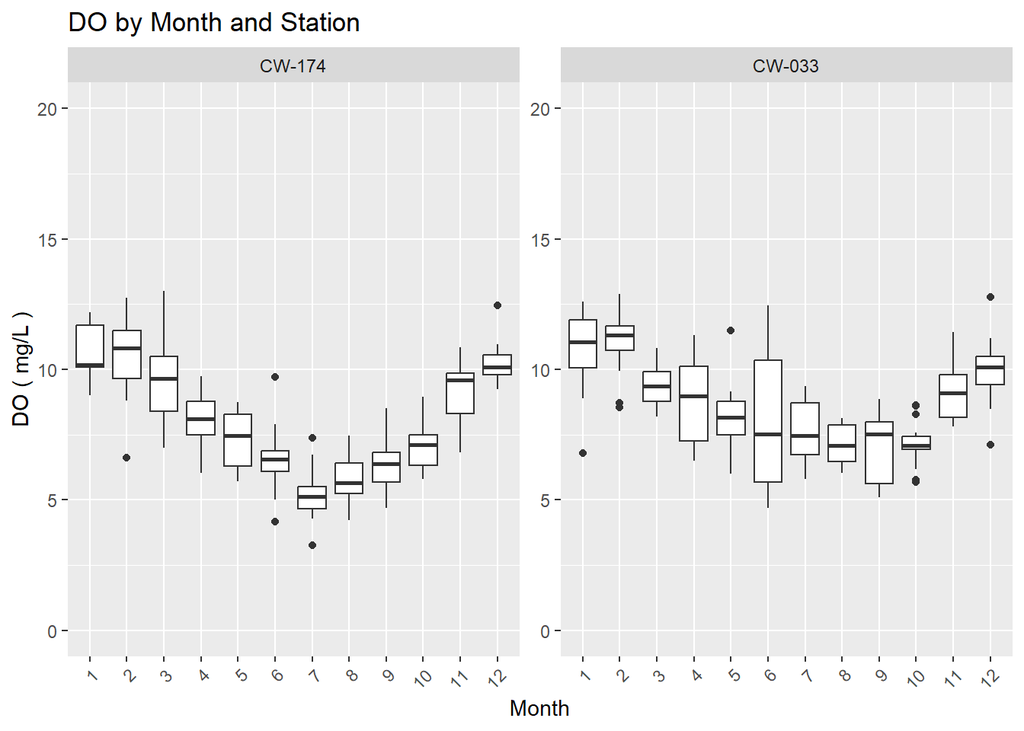

Figure X - Seasonal pattern in DO at Cedar Creek Reservoir stations.

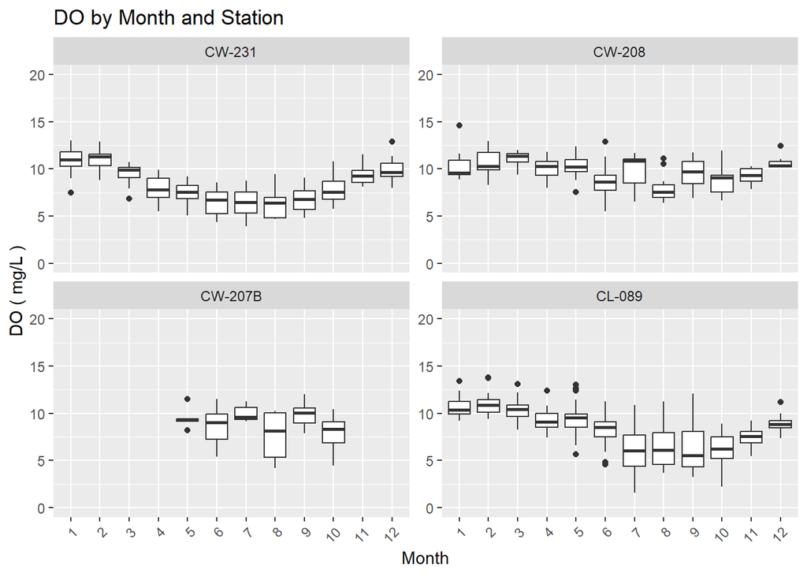

Figure X - Seasonal pattern in DO at Lake Wateree Reservoir stations.

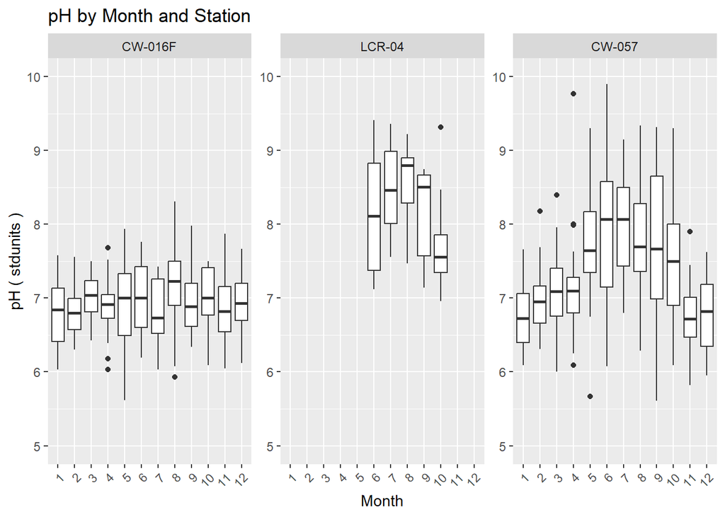

Figure X - Seasonal pattern in pH at Fishing Creek Reservoir stations.

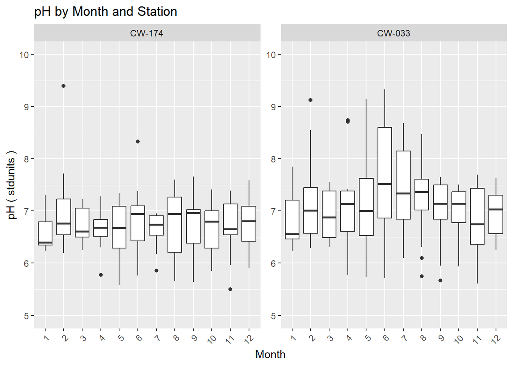

Figure X - Seasonal pattern in pH at Cedar Creek Reservoir stations.

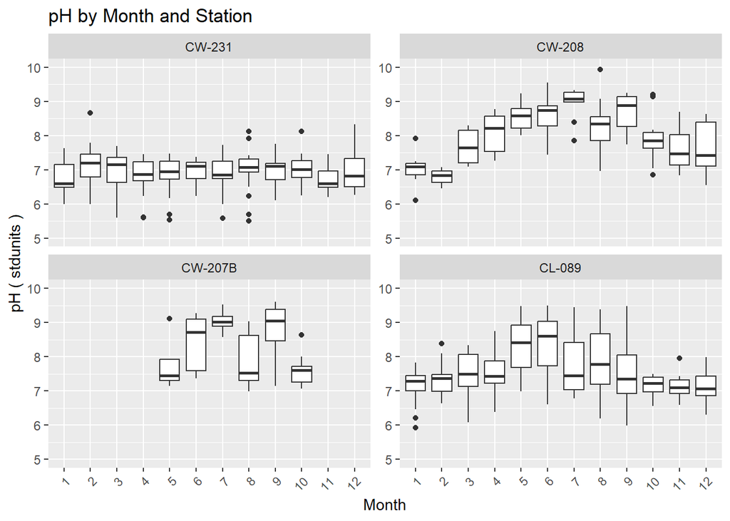

Figure X - Seasonal pattern in pH at Lake Wateree stations.

## Summary Tables for Chlorophyll-a, DO, pH, and Secchi depth

The following tables present summary statistics for chla, DO, pH, and Secchi depth by reservoir and station. The stats are calculated from data from the growing season, <= 1 m depth, and stations with at least five data.

All values in ug/L except Count

| StationID | Chla in FISHING CREEK RESERVOIR Count | Chla in FISHING CREEK RESERVOIR Max | Chla in FISHING CREEK RESERVOIR Perc_90th | Chla in FISHING CREEK RESERVOIR Perc_75th | Chla in FISHING CREEK RESERVOIR Arith_Mean | Chla in FISHING CREEK RESERVOIR Geo_Mean | Chla in FISHING CREEK RESERVOIR Median | Chla in FISHING CREEK RESERVOIR Perc_25th | Chla in FISHING CREEK RESERVOIR Perc_10th | Chla in FISHING CREEK RESERVOIR Min |
| --- | --- | --- | --- | --- | --- | --- | --- | --- | --- | --- |
| CW-016F | 80 | 58.2 | 23.8 | 9.4 | 9.1 | 5.7 | 4.3 | 3.2 | 2.2 | 0.8 |
| RL-21226 | 6 | 17.5 | 11.6 | 5.7 | 6.8 | 5.8 | 5.2 | 4.0 | 3.8 | 3.8 |
| RL-21210 | 7 | 16.9 | 9.8 | 4.4 | 5.6 | 4.5 | 3.6 | 3.3 | 3.1 | 3.0 |
| LCR-01 | 12 | 26.8 | 21.2 | 17.3 | 12.9 | 10.9 | 11.4 | 7.6 | 4.4 | 3.6 |
| RL-01012 | 6 | 73.8 | 66.7 | 55.1 | 41.4 | 34.7 | 36.9 | 31.8 | 20.5 | 9.3 |
| RL-22013 | 6 | 50.2 | 38.6 | 26.9 | 23.8 | 20.1 | 22.9 | 13.6 | 9.8 | 8.0 |
| LCR-05 | 12 | 51.7 | 39.9 | 36.4 | 27.8 | 25.8 | 25.9 | 17.6 | 16.9 | 16.7 |
| LCR-04 | 44 | 44.8 | 32.5 | 26.2 | 21.0 | 19.0 | 19.0 | 14.8 | 11.5 | 4.6 |
| CW-057 | 139 | 75.7 | 38.5 | 28.4 | 21.5 | 17.9 | 19.8 | 13.3 | 6.6 | 2.5 |

All values in ug/L except Count

| StationID | Chla in GREAT FALLS RESERVOIR Count | Chla in GREAT FALLS RESERVOIR Max | Chla in GREAT FALLS RESERVOIR Perc_90th | Chla in GREAT FALLS RESERVOIR Perc_75th | Chla in GREAT FALLS RESERVOIR Arith_Mean | Chla in GREAT FALLS RESERVOIR Geo_Mean | Chla in GREAT FALLS RESERVOIR Median | Chla in GREAT FALLS RESERVOIR Perc_25th | Chla in GREAT FALLS RESERVOIR Perc_10th | Chla in GREAT FALLS RESERVOIR Min |
| --- | --- | --- | --- | --- | --- | --- | --- | --- | --- | --- |
| RL-06429 | 6 | 36.3 | 28.5 | 20.5 | 15.8 | 11 | 15.7 | 5.5 | 3.2 | 2.8 |

All values in ug/L except Count

| StationID | Chla in CEDAR CREEK RESERVOIR Count | Chla in CEDAR CREEK RESERVOIR Max | Chla in CEDAR CREEK RESERVOIR Perc_90th | Chla in CEDAR CREEK RESERVOIR Perc_75th | Chla in CEDAR CREEK RESERVOIR Arith_Mean | Chla in CEDAR CREEK RESERVOIR Geo_Mean | Chla in CEDAR CREEK RESERVOIR Median | Chla in CEDAR CREEK RESERVOIR Perc_25th | Chla in CEDAR CREEK RESERVOIR Perc_10th | Chla in CEDAR CREEK RESERVOIR Min |
| --- | --- | --- | --- | --- | --- | --- | --- | --- | --- | --- |
| RL-04379 | 6 | 21.6 | 17.4 | 12.6 | 10.0 | 7.5 | 10.2 | 4.3 | 2.4 | 2.3 |
| RL-19254 | 6 | 34.4 | 32.3 | 28.2 | 22.5 | 21.3 | 19.9 | 17.0 | 15.2 | 13.7 |
| RL-01007 | 6 | 55.8 | 54.4 | 49.2 | 31.2 | 23.9 | 30.8 | 13.6 | 8.5 | 6.8 |
| RL-23120 | 6 | 37.9 | 30.9 | 23.5 | 20.7 | 19.0 | 19.4 | 13.2 | 11.8 | 11.5 |
| CW-174 | 55 | 32.0 | 10.2 | 7.2 | 5.8 | 4.8 | 4.5 | 3.2 | 2.5 | 1.4 |
| RL-19149 | 13 | 45.7 | 38.3 | 26.2 | 21.7 | 17.6 | 18.9 | 15.5 | 6.1 | 4.1 |
| RL-04375 | 6 | 36.1 | 32.6 | 29.0 | 21.8 | 16.5 | 27.7 | 10.5 | 5.0 | 4.9 |
| RL-14147 | 6 | 36.0 | 27.5 | 18.4 | 18.7 | 17.3 | 16.1 | 13.4 | 12.4 | 12.1 |
| RL-21277 | 8 | 26.2 | 20.5 | 17.9 | 11.7 | 9.4 | 7.8 | 6.5 | 4.2 | 4.0 |
| RL-06443 | 7 | 36.4 | 28.6 | 22.8 | 16.6 | 13.0 | 15.1 | 7.5 | 5.6 | 4.0 |
| RL-02319 | 9 | 38.3 | 27.3 | 13.2 | 12.9 | 9.0 | 11.3 | 4.2 | 3.4 | 2.4 |
| RL-01017 | 6 | 41.0 | 35.1 | 26.4 | 19.6 | 16.3 | 15.2 | 10.2 | 8.5 | 7.4 |
| RL-23116 | 6 | 28.8 | 27.7 | 25.0 | 19.2 | 17.6 | 20.1 | 13.6 | 10.0 | 8.5 |
| CW-033 | 95 | 33.0 | 25.9 | 18.9 | 13.9 | 11.5 | 12.2 | 8.5 | 4.0 | 1.8 |
| RL-18146 | 6 | 38.6 | 38.3 | 36.1 | 25.3 | 23.0 | 24.1 | 15.0 | 13.6 | 13.2 |

All values in ug/L except Count

| StationID | Chla in LAKE WATEREE Count | Chla in LAKE WATEREE Max | Chla in LAKE WATEREE Perc_90th | Chla in LAKE WATEREE Perc_75th | Chla in LAKE WATEREE Arith_Mean | Chla in LAKE WATEREE Geo_Mean | Chla in LAKE WATEREE Median | Chla in LAKE WATEREE Perc_25th | Chla in LAKE WATEREE Perc_10th | Chla in LAKE WATEREE Min |
| --- | --- | --- | --- | --- | --- | --- | --- | --- | --- | --- |
| CW-231 | 115 | 15.8 | 10.2 | 7.9 | 5.8 | 4.9 | 4.9 | 3.7 | 2.1 | 0.5 |
| LCR-02 | 54 | 61.0 | 27.1 | 17.4 | 13.4 | 10.3 | 11.3 | 5.8 | 4.1 | 3.0 |
| RL-11040 | 6 | 44.3 | 36.3 | 26.2 | 22.0 | 18.0 | 19.4 | 16.7 | 10.3 | 4.6 |
| RL-19166 | 7 | 38.0 | 37.8 | 37.5 | 30.3 | 29.3 | 33.3 | 22.4 | 21.0 | 20.9 |
| CW-208 | 69 | 61.6 | 45.5 | 40.0 | 32.8 | 31.0 | 32.9 | 25.8 | 18.6 | 9.7 |
| LCR-03 | 39 | 72.3 | 39.3 | 28.9 | 23.2 | 20.0 | 22.1 | 14.0 | 10.1 | 4.6 |
| RL-23029 | 6 | 42.7 | 35.3 | 26.7 | 22.9 | 20.8 | 20.4 | 16.2 | 13.1 | 10.5 |
| CW-207 | 59 | 46.0 | 36.2 | 32.2 | 24.7 | 22.8 | 23.1 | 17.8 | 13.8 | 6.7 |
| CW-207A | 18 | 37.3 | 32.0 | 28.2 | 21.9 | 18.7 | 22.6 | 18.1 | 6.9 | 2.8 |
| CW-207B | 65 | 60.1 | 34.4 | 26.9 | 24.4 | 22.8 | 22.7 | 18.7 | 15.5 | 7.7 |
| RL-14155 | 7 | 21.1 | 21.0 | 17.9 | 14.5 | 13.3 | 14.7 | 12.7 | 9.3 | 4.7 |
| RL-23045 | 6 | 21.1 | 20.9 | 20.5 | 18.7 | 18.5 | 19.2 | 18.0 | 15.9 | 13.9 |
| RL-01003 | 6 | 26.6 | 25.8 | 24.6 | 18.8 | 17.0 | 21.1 | 14.2 | 9.5 | 6.4 |
| CW-209 | 17 | 30.5 | 25.7 | 21.6 | 19.6 | 18.9 | 19.5 | 17.1 | 12.8 | 11.2 |
| RL-01033 | 6 | 23.0 | 21.0 | 18.0 | 14.7 | 13.8 | 14.5 | 10.2 | 8.7 | 8.4 |
| WA-DW-2 | 6 | 25.8 | 23.1 | 19.4 | 17.3 | 16.8 | 16.5 | 13.7 | 12.5 | 12.2 |
| CW-712 | 6 | 25.8 | 23.1 | 19.4 | 17.3 | 16.8 | 16.5 | 13.7 | 12.5 | 12.2 |
| RL-22011 | 6 | 24.2 | 22.9 | 20.9 | 17.5 | 16.8 | 18.0 | 13.5 | 11.6 | 11.0 |
| CL-089 | 143 | 41.5 | 25.5 | 20.1 | 15.9 | 14.3 | 14.7 | 10.5 | 7.9 | 2.4 |
| WA-DW-1 | 6 | 34.0 | 26.1 | 18.0 | 17.3 | 15.5 | 16.8 | 11.8 | 9.0 | 7.8 |
| CW-711 | 6 | 34.0 | 26.1 | 18.0 | 17.3 | 15.5 | 16.8 | 11.8 | 9.0 | 7.8 |

All values in mg/L except Count

| StationID | DO in FISHING CREEK RESERVOIR Count | DO in FISHING CREEK RESERVOIR Max | DO in FISHING CREEK RESERVOIR Perc_90th | DO in FISHING CREEK RESERVOIR Perc_75th | DO in FISHING CREEK RESERVOIR Arith_Mean | DO in FISHING CREEK RESERVOIR Geo_Mean | DO in FISHING CREEK RESERVOIR Median | DO in FISHING CREEK RESERVOIR Perc_25th | DO in FISHING CREEK RESERVOIR Perc_10th | DO in FISHING CREEK RESERVOIR Min |
| --- | --- | --- | --- | --- | --- | --- | --- | --- | --- | --- |
| CW-016F | 101 | 10.8 | 8.8 | 8.0 | 7.4 | 7.3 | 7.3 | 6.8 | 6.1 | 4.8 |
| RL-21226 | 7 | 9.0 | 8.6 | 8.0 | 7.2 | 7.2 | 6.8 | 6.5 | 6.2 | 5.8 |
| RL-17071 | 7 | 7.9 | 7.6 | 7.3 | 6.8 | 6.7 | 7.0 | 6.4 | 5.7 | 5.2 |
| RL-21210 | 7 | 8.4 | 8.2 | 8.0 | 7.3 | 7.2 | 7.7 | 6.5 | 6.1 | 5.9 |
| LCR-01 | 11 | 10.1 | 8.8 | 8.5 | 8.2 | 8.1 | 8.0 | 7.7 | 7.4 | 7.2 |
| RL-13072 | 7 | 9.2 | 9.0 | 8.4 | 7.8 | 7.7 | 7.5 | 7.3 | 6.9 | 6.5 |
| RL-01012 | 6 | 12.7 | 11.9 | 11.0 | 9.4 | 9.2 | 9.5 | 7.4 | 6.9 | 6.6 |
| RL-15023 | 7 | 10.2 | 9.0 | 8.1 | 8.0 | 8.0 | 7.7 | 7.4 | 7.3 | 7.3 |
| RL-22013 | 7 | 11.0 | 9.7 | 8.7 | 8.7 | 8.6 | 8.5 | 8.0 | 7.7 | 7.7 |
| LCR-05 | 11 | 11.7 | 10.6 | 9.7 | 8.8 | 8.7 | 8.8 | 7.6 | 6.8 | 6.7 |
| LCR-04 | 42 | 12.0 | 11.1 | 9.6 | 9.0 | 8.9 | 8.9 | 7.9 | 7.5 | 6.6 |
| CW-057 | 168 | 15.2 | 10.9 | 9.7 | 8.8 | 8.6 | 8.6 | 7.6 | 6.7 | 2.0 |

All values in mg/L except Count

| StationID | DO in GREAT FALLS RESERVOIR Count | DO in GREAT FALLS RESERVOIR Max | DO in GREAT FALLS RESERVOIR Perc_90th | DO in GREAT FALLS RESERVOIR Perc_75th | DO in GREAT FALLS RESERVOIR Arith_Mean | DO in GREAT FALLS RESERVOIR Geo_Mean | DO in GREAT FALLS RESERVOIR Median | DO in GREAT FALLS RESERVOIR Perc_25th | DO in GREAT FALLS RESERVOIR Perc_10th | DO in GREAT FALLS RESERVOIR Min |
| --- | --- | --- | --- | --- | --- | --- | --- | --- | --- | --- |
| RL-05414 | 6 | 10.6 | 9.4 | 8.1 | 7.1 | 6.9 | 6.8 | 5.9 | 5.2 | 4.5 |
| RL-03332 | 6 | 8.5 | 8.0 | 7.4 | 6.9 | 6.8 | 6.8 | 6.1 | 5.9 | 5.7 |
| RL-03458 | 6 | 8.4 | 8.1 | 7.6 | 6.8 | 6.8 | 6.7 | 6.0 | 5.8 | 5.6 |
| RL-08062 | 7 | 7.0 | 7.0 | 6.7 | 5.8 | 5.8 | 5.7 | 5.3 | 4.8 | 4.2 |
| RL-13134 | 7 | 8.2 | 8.0 | 7.5 | 6.7 | 6.6 | 6.8 | 6.1 | 5.3 | 4.6 |
| RL-03351 | 6 | 8.4 | 8.2 | 7.8 | 6.8 | 6.7 | 6.7 | 5.6 | 5.5 | 5.4 |
| RL-06429 | 14 | 10.8 | 7.9 | 7.0 | 6.4 | 6.3 | 6.3 | 5.4 | 4.8 | 4.4 |
| RL-11117 | 7 | 6.0 | 5.9 | 5.5 | 4.5 | 4.4 | 4.6 | 3.6 | 2.9 | 2.9 |

All values in mg/L except Count

| StationID | DO in CEDAR CREEK RESERVOIR Count | DO in CEDAR CREEK RESERVOIR Max | DO in CEDAR CREEK RESERVOIR Perc_90th | DO in CEDAR CREEK RESERVOIR Perc_75th | DO in CEDAR CREEK RESERVOIR Arith_Mean | DO in CEDAR CREEK RESERVOIR Geo_Mean | DO in CEDAR CREEK RESERVOIR Median | DO in CEDAR CREEK RESERVOIR Perc_25th | DO in CEDAR CREEK RESERVOIR Perc_10th | DO in CEDAR CREEK RESERVOIR Min |
| --- | --- | --- | --- | --- | --- | --- | --- | --- | --- | --- |
| RL-04379 | 7 | 12.0 | 10.6 | 9.5 | 8.7 | 8.5 | 8.6 | 7.2 | 7.0 | 6.7 |
| RL-15104 | 7 | 10.4 | 10.0 | 8.7 | 8.2 | 8.1 | 7.6 | 7.5 | 7.4 | 7.3 |
| RL-06431 | 7 | 6.9 | 6.9 | 6.7 | 5.8 | 5.7 | 6.2 | 5.2 | 4.7 | 3.8 |
| RL-10102 | 7 | 11.2 | 10.5 | 9.5 | 8.5 | 8.4 | 7.8 | 7.5 | 7.2 | 6.9 |
| RL-19254 | 7 | 9.9 | 9.7 | 9.1 | 8.8 | 8.8 | 8.6 | 8.4 | 8.3 | 8.1 |
| RL-01007 | 14 | 11.0 | 9.4 | 8.7 | 7.7 | 7.4 | 8.2 | 7.3 | 4.5 | 3.9 |
| CW-174 | 89 | 9.8 | 8.4 | 7.5 | 6.6 | 6.5 | 6.6 | 5.5 | 4.9 | 3.3 |
| RL-19149 | 13 | 11.5 | 11.1 | 9.3 | 9.0 | 9.0 | 8.6 | 8.4 | 8.0 | 7.9 |
| CW-175 | 26 | 9.0 | 7.9 | 6.9 | 6.2 | 6.0 | 6.2 | 5.0 | 4.6 | 3.4 |
| RL-04375 | 7 | 13.3 | 12.5 | 11.3 | 10.0 | 9.8 | 9.6 | 8.3 | 7.6 | 7.6 |
| RL-07003 | 7 | 10.8 | 10.6 | 9.2 | 7.8 | 7.6 | 7.3 | 6.5 | 5.7 | 5.4 |
| RL-05391 | 7 | 11.2 | 10.5 | 9.8 | 8.2 | 7.9 | 7.7 | 6.4 | 6.0 | 5.9 |
| RL-03353 | 7 | 10.6 | 10.2 | 9.5 | 8.3 | 8.1 | 8.0 | 7.6 | 6.5 | 5.2 |
| RL-14147 | 7 | 10.9 | 10.8 | 9.8 | 8.3 | 8.0 | 8.3 | 7.2 | 5.9 | 4.7 |
| RL-08046 | 7 | 7.2 | 7.2 | 7.1 | 6.3 | 6.1 | 6.9 | 5.8 | 4.7 | 4.0 |
| RL-17127 | 7 | 12.1 | 10.9 | 10.1 | 9.5 | 9.3 | 10.0 | 8.6 | 7.6 | 6.9 |
| RL-21277 | 7 | 10.9 | 10.6 | 9.4 | 8.5 | 8.4 | 8.3 | 7.7 | 7.0 | 6.4 |
| RL-06443 | 8 | 10.3 | 8.8 | 7.9 | 7.5 | 7.4 | 7.1 | 6.6 | 6.5 | 6.4 |
| RL-22105 | 6 | 11.8 | 10.4 | 8.9 | 8.9 | 8.8 | 8.5 | 8.2 | 7.8 | 7.4 |
| RL-16115 | 7 | 13.4 | 10.1 | 7.7 | 7.8 | 7.5 | 7.3 | 6.4 | 6.0 | 5.7 |
| RL-02319 | 11 | 9.9 | 8.6 | 7.6 | 7.2 | 7.1 | 6.9 | 6.6 | 6.3 | 5.5 |
| RL-01017 | 6 | 9.3 | 9.2 | 8.9 | 7.2 | 6.9 | 7.8 | 5.6 | 4.5 | 4.0 |
| RL-12125 | 7 | 9.8 | 8.8 | 7.9 | 7.6 | 7.6 | 7.4 | 7.1 | 6.7 | 6.4 |
| CW-033 | 98 | 12.4 | 10.2 | 8.7 | 7.8 | 7.6 | 7.5 | 6.6 | 5.8 | 4.7 |
| RL-18146 | 6 | 10.7 | 9.8 | 8.7 | 7.9 | 7.8 | 7.5 | 6.6 | 6.4 | 6.3 |
| RL-05416 | 7 | 8.5 | 8.0 | 7.6 | 7.0 | 6.9 | 7.1 | 6.2 | 5.8 | 5.8 |
| RL-09094 | 6 | 10.7 | 10.7 | 10.4 | 8.6 | 8.4 | 8.9 | 6.8 | 6.2 | 6.0 |

All values in mg/L except Count

| StationID | DO in LAKE WATEREE Count | DO in LAKE WATEREE Max | DO in LAKE WATEREE Perc_90th | DO in LAKE WATEREE Perc_75th | DO in LAKE WATEREE Arith_Mean | DO in LAKE WATEREE Geo_Mean | DO in LAKE WATEREE Median | DO in LAKE WATEREE Perc_25th | DO in LAKE WATEREE Perc_10th | DO in LAKE WATEREE Min |
| --- | --- | --- | --- | --- | --- | --- | --- | --- | --- | --- |
| CW-231 | 149 | 10.8 | 8.8 | 8.0 | 7.0 | 6.8 | 7.0 | 5.8 | 5.0 | 4.0 |
| RL-15007 | 6 | 8.4 | 8.3 | 7.8 | 6.9 | 6.8 | 6.4 | 6.2 | 6.0 | 5.9 |
| LCR-02 | 41 | 10.9 | 9.4 | 8.9 | 8.3 | 8.2 | 8.2 | 7.5 | 7.2 | 6.3 |
| RL-11040 | 7 | 10.9 | 9.1 | 7.8 | 7.3 | 7.1 | 7.2 | 6.2 | 5.3 | 5.0 |
| RL-19166 | 7 | 11.6 | 11.3 | 10.8 | 10.3 | 10.3 | 10.5 | 9.8 | 9.3 | 8.9 |
| CW-208 | 70 | 12.8 | 11.5 | 10.8 | 9.2 | 9.1 | 9.2 | 7.9 | 6.9 | 5.5 |
| RL-12056 | 6 | 10.3 | 9.8 | 9.4 | 8.3 | 8.1 | 9.0 | 7.2 | 6.1 | 5.6 |
| RL-08035 | 7 | 10.6 | 10.2 | 9.4 | 8.3 | 8.2 | 8.6 | 7.0 | 6.6 | 6.6 |
| LCR-03 | 32 | 12.0 | 11.3 | 10.7 | 9.4 | 9.2 | 9.4 | 8.2 | 7.2 | 6.1 |
| RL-16039 | 7 | 13.8 | 11.7 | 9.6 | 8.5 | 8.1 | 8.2 | 6.8 | 5.3 | 4.9 |
| RL-13084 | 7 | 12.0 | 11.9 | 11.2 | 9.3 | 9.1 | 8.5 | 8.2 | 7.3 | 6.0 |
| RL-02314 | 7 | 11.1 | 10.6 | 9.8 | 8.7 | 8.6 | 9.1 | 7.4 | 6.9 | 6.4 |
| RL-17055 | 7 | 11.2 | 10.6 | 9.6 | 9.0 | 9.0 | 8.8 | 8.4 | 7.9 | 7.3 |
| CW-207 | 90 | 13.5 | 10.9 | 10.1 | 8.8 | 8.7 | 8.9 | 7.6 | 6.7 | 5.0 |
| CW-207A | 16 | 11.2 | 10.6 | 10.3 | 9.4 | 9.4 | 8.9 | 8.5 | 8.4 | 8.2 |
| CW-207B | 53 | 12.0 | 11.2 | 10.2 | 8.9 | 8.6 | 9.2 | 8.0 | 5.4 | 4.2 |
| RL-21218 | 6 | 11.8 | 11.6 | 11.0 | 9.5 | 9.3 | 9.3 | 8.7 | 7.5 | 6.4 |
| RL-14155 | 8 | 9.6 | 9.0 | 8.4 | 7.4 | 7.3 | 7.7 | 6.4 | 5.2 | 5.2 |
| RL-03336 | 7 | 10.8 | 10.0 | 9.2 | 8.6 | 8.5 | 8.7 | 7.7 | 7.4 | 7.0 |
| RL-09099 | 6 | 9.9 | 9.6 | 9.2 | 8.2 | 8.2 | 8.4 | 7.1 | 6.8 | 6.7 |
| RL-10008 | 7 | 10.4 | 9.8 | 9.3 | 8.6 | 8.5 | 8.9 | 8.1 | 7.0 | 6.2 |
| RL-01003 | 6 | 10.7 | 10.2 | 9.8 | 8.6 | 8.3 | 9.6 | 7.6 | 6.0 | 5.0 |
| CW-209 | 28 | 11.2 | 10.0 | 8.7 | 7.8 | 7.7 | 7.8 | 6.4 | 5.7 | 4.9 |
| RL-20198 | 7 | 10.7 | 10.2 | 9.7 | 8.8 | 8.8 | 8.7 | 7.8 | 7.6 | 7.5 |
| RL-01033 | 6 | 17.0 | 13.6 | 10.0 | 10.0 | 9.5 | 9.3 | 8.8 | 7.2 | 5.8 |
| RL-22011 | 6 | 11.0 | 9.9 | 8.8 | 7.4 | 7.1 | 7.5 | 5.8 | 4.8 | 4.1 |
| CL-089 | 160 | 13.0 | 10.1 | 9.1 | 7.4 | 7.0 | 7.7 | 5.5 | 4.3 | 1.6 |

All values in stdunits except Count

| StationID | pH in FISHING CREEK RESERVOIR Count | pH in FISHING CREEK RESERVOIR Max | pH in FISHING CREEK RESERVOIR Perc_90th | pH in FISHING CREEK RESERVOIR Perc_75th | pH in FISHING CREEK RESERVOIR Arith_Mean | pH in FISHING CREEK RESERVOIR Geo_Mean | pH in FISHING CREEK RESERVOIR Median | pH in FISHING CREEK RESERVOIR Perc_25th | pH in FISHING CREEK RESERVOIR Perc_10th | pH in FISHING CREEK RESERVOIR Min |
| --- | --- | --- | --- | --- | --- | --- | --- | --- | --- | --- |
| CW-016F | 102 | 8.3 | 7.5 | 7.3 | 7.0 | 7.0 | 7.0 | 6.6 | 6.3 | 5.6 |
| RL-21226 | 7 | 7.1 | 7.1 | 7.0 | 6.9 | 6.9 | 6.9 | 6.8 | 6.7 | 6.6 |
| RL-17071 | 7 | 7.6 | 7.2 | 6.9 | 6.5 | 6.5 | 6.3 | 6.0 | 5.8 | 5.6 |
| RL-21210 | 7 | 7.5 | 7.4 | 7.2 | 7.0 | 7.0 | 7.0 | 6.9 | 6.8 | 6.7 |
| LCR-01 | 11 | 8.7 | 8.2 | 8.1 | 7.8 | 7.8 | 7.8 | 7.5 | 7.4 | 6.8 |
| RL-13072 | 7 | 7.8 | 7.6 | 7.1 | 6.8 | 6.8 | 6.5 | 6.5 | 6.3 | 6.1 |
| RL-01012 | 6 | 9.0 | 8.7 | 8.1 | 7.6 | 7.5 | 7.3 | 7.0 | 6.7 | 6.4 |
| RL-15023 | 7 | 7.7 | 7.4 | 6.8 | 6.5 | 6.5 | 6.3 | 6.2 | 5.9 | 5.7 |
| RL-22013 | 7 | 9.3 | 8.9 | 8.5 | 8.0 | 8.0 | 7.5 | 7.4 | 7.3 | 7.3 |
| LCR-05 | 11 | 9.4 | 9.1 | 8.9 | 8.5 | 8.5 | 8.5 | 8.4 | 7.4 | 7.3 |
| LCR-04 | 43 | 9.4 | 9.2 | 8.8 | 8.1 | 8.0 | 8.1 | 7.5 | 7.1 | 6.7 |
| CW-057 | 169 | 9.9 | 9.1 | 8.3 | 7.7 | 7.6 | 7.6 | 7.0 | 6.6 | 5.6 |

All values in stdunits except Count

| StationID | pH in GREAT FALLS RESERVOIR Count | pH in GREAT FALLS RESERVOIR Max | pH in GREAT FALLS RESERVOIR Perc_90th | pH in GREAT FALLS RESERVOIR Perc_75th | pH in GREAT FALLS RESERVOIR Arith_Mean | pH in GREAT FALLS RESERVOIR Geo_Mean | pH in GREAT FALLS RESERVOIR Median | pH in GREAT FALLS RESERVOIR Perc_25th | pH in GREAT FALLS RESERVOIR Perc_10th | pH in GREAT FALLS RESERVOIR Min |
| --- | --- | --- | --- | --- | --- | --- | --- | --- | --- | --- |
| RL-05414 | 6 | 8.1 | 7.6 | 7.2 | 7.2 | 7.2 | 7.1 | 7.0 | 6.9 | 6.9 |
| RL-03332 | 6 | 6.9 | 6.8 | 6.7 | 6.6 | 6.6 | 6.7 | 6.5 | 6.3 | 6.2 |
| RL-03458 | 6 | 6.8 | 6.8 | 6.8 | 6.6 | 6.6 | 6.8 | 6.5 | 6.3 | 6.2 |
| RL-08062 | 7 | 7.2 | 7.1 | 7.1 | 6.9 | 6.9 | 7.1 | 6.8 | 6.5 | 6.4 |
| RL-13134 | 7 | 7.4 | 7.2 | 6.6 | 6.3 | 6.3 | 6.1 | 5.9 | 5.8 | 5.8 |
| RL-03351 | 6 | 7.0 | 6.9 | 6.9 | 6.7 | 6.7 | 6.8 | 6.5 | 6.3 | 6.3 |
| RL-06429 | 14 | 8.6 | 7.3 | 7.3 | 7.2 | 7.2 | 7.2 | 7.1 | 6.7 | 6.6 |
| RL-11117 | 7 | 6.7 | 6.7 | 6.7 | 6.6 | 6.6 | 6.5 | 6.5 | 6.4 | 6.3 |

All values in stdunits except Count

| StationID | pH in CEDAR CREEK RESERVOIR Count | pH in CEDAR CREEK RESERVOIR Max | pH in CEDAR CREEK RESERVOIR Perc_90th | pH in CEDAR CREEK RESERVOIR Perc_75th | pH in CEDAR CREEK RESERVOIR Arith_Mean | pH in CEDAR CREEK RESERVOIR Geo_Mean | pH in CEDAR CREEK RESERVOIR Median | pH in CEDAR CREEK RESERVOIR Perc_25th | pH in CEDAR CREEK RESERVOIR Perc_10th | pH in CEDAR CREEK RESERVOIR Min |
| --- | --- | --- | --- | --- | --- | --- | --- | --- | --- | --- |
| RL-04379 | 7 | 8.1 | 7.7 | 7.5 | 7.1 | 7.1 | 7.2 | 6.7 | 6.3 | 6.0 |
| RL-15104 | 7 | 7.7 | 7.4 | 6.9 | 6.5 | 6.5 | 6.5 | 6.1 | 5.8 | 5.6 |
| RL-06431 | 7 | 7.5 | 7.4 | 7.2 | 7.2 | 7.1 | 7.1 | 7.0 | 7.0 | 6.9 |
| RL-10102 | 7 | 8.2 | 8.2 | 7.8 | 6.9 | 6.7 | 7.1 | 7.0 | 5.6 | 3.5 |
| RL-19254 | 7 | 8.1 | 8.1 | 8.1 | 7.7 | 7.6 | 7.5 | 7.4 | 7.3 | 7.2 |
| RL-01007 | 14 | 8.5 | 8.2 | 7.5 | 7.3 | 7.2 | 7.2 | 6.8 | 6.6 | 6.5 |
| CW-174 | 90 | 8.3 | 7.3 | 7.1 | 6.7 | 6.7 | 6.8 | 6.3 | 5.9 | 5.6 |
| RL-19149 | 14 | 9.4 | 8.5 | 8.3 | 7.8 | 7.8 | 7.9 | 7.3 | 6.8 | 6.5 |
| CW-175 | 26 | 7.3 | 7.2 | 7.1 | 6.9 | 6.9 | 6.9 | 6.7 | 6.5 | 6.2 |
| RL-04375 | 7 | 8.7 | 8.4 | 8.2 | 7.5 | 7.5 | 7.7 | 6.9 | 6.3 | 6.2 |
| RL-07003 | 7 | 9.1 | 8.8 | 8.6 | 8.0 | 8.0 | 8.4 | 7.1 | 7.0 | 6.9 |
| RL-05391 | 7 | 9.1 | 8.6 | 7.6 | 7.4 | 7.3 | 7.0 | 6.9 | 6.7 | 6.5 |
| RL-03353 | 7 | 7.5 | 7.3 | 7.0 | 6.9 | 6.9 | 7.0 | 6.8 | 6.4 | 6.0 |
| RL-14147 | 7 | 8.9 | 8.4 | 8.1 | 7.9 | 7.9 | 7.8 | 7.6 | 7.3 | 7.1 |
| RL-08046 | 7 | 7.4 | 7.2 | 7.1 | 6.8 | 6.8 | 6.9 | 6.7 | 6.4 | 5.9 |
| RL-17127 | 7 | 9.1 | 9.0 | 8.5 | 7.8 | 7.8 | 7.4 | 7.1 | 7.0 | 7.0 |
| RL-21277 | 7 | 8.8 | 8.5 | 7.6 | 7.3 | 7.3 | 7.0 | 6.9 | 6.7 | 6.6 |
| RL-06443 | 8 | 8.6 | 8.5 | 8.5 | 7.8 | 7.8 | 7.8 | 7.3 | 7.1 | 7.1 |
| RL-22105 | 6 | 9.1 | 8.7 | 8.3 | 8.0 | 8.0 | 8.0 | 7.6 | 7.5 | 7.3 |
| RL-16115 | 7 | 8.9 | 8.1 | 7.2 | 7.0 | 6.9 | 6.6 | 6.3 | 6.2 | 6.2 |
| RL-02319 | 12 | 8.0 | 7.5 | 7.3 | 7.0 | 7.0 | 7.0 | 6.7 | 6.5 | 6.5 |
| RL-01017 | 6 | 7.4 | 7.3 | 7.2 | 6.9 | 6.9 | 6.9 | 6.7 | 6.6 | 6.5 |
| RL-12125 | 7 | 8.4 | 8.1 | 7.8 | 7.7 | 7.7 | 7.6 | 7.4 | 7.4 | 7.4 |
| CW-033 | 99 | 9.3 | 8.4 | 7.6 | 7.2 | 7.2 | 7.2 | 6.7 | 6.1 | 5.7 |
| RL-18146 | 6 | 7.3 | 7.1 | 6.9 | 6.7 | 6.6 | 6.6 | 6.3 | 6.2 | 6.2 |
| RL-05416 | 7 | 7.2 | 7.2 | 7.2 | 6.9 | 6.9 | 7.0 | 6.8 | 6.5 | 6.3 |
| RL-09094 | 6 | 8.3 | 8.3 | 8.1 | 7.6 | 7.6 | 7.6 | 7.1 | 6.9 | 6.9 |

All values in stdunits except Count

| StationID | pH in LAKE WATEREE Count | pH in LAKE WATEREE Max | pH in LAKE WATEREE Perc_90th | pH in LAKE WATEREE Perc_75th | pH in LAKE WATEREE Arith_Mean | pH in LAKE WATEREE Geo_Mean | pH in LAKE WATEREE Median | pH in LAKE WATEREE Perc_25th | pH in LAKE WATEREE Perc_10th | pH in LAKE WATEREE Min |
| --- | --- | --- | --- | --- | --- | --- | --- | --- | --- | --- |
| CW-231 | 149 | 8.1 | 7.4 | 7.2 | 6.9 | 6.9 | 7.0 | 6.7 | 6.3 | 5.5 |
| RL-15007 | 6 | 7.6 | 7.5 | 7.5 | 7.3 | 7.3 | 7.3 | 7.2 | 7.1 | 7.1 |
| LCR-02 | 42 | 8.6 | 7.9 | 7.7 | 7.5 | 7.5 | 7.4 | 7.2 | 7.0 | 6.8 |
| RL-11040 | 7 | 8.8 | 8.4 | 7.9 | 7.5 | 7.5 | 7.3 | 7.0 | 6.7 | 6.5 |
| RL-19166 | 7 | 9.2 | 9.1 | 9.1 | 8.7 | 8.6 | 8.8 | 8.4 | 8.1 | 7.7 |
| CW-208 | 69 | 9.9 | 9.2 | 9.0 | 8.4 | 8.4 | 8.5 | 7.9 | 7.5 | 6.9 |
| RL-12056 | 6 | 8.6 | 8.5 | 8.4 | 8.2 | 8.2 | 8.2 | 8.1 | 7.8 | 7.6 |
| RL-08035 | 7 | 9.1 | 9.0 | 8.7 | 8.2 | 8.2 | 8.2 | 7.7 | 7.5 | 7.2 |
| LCR-03 | 32 | 9.6 | 9.2 | 9.0 | 8.2 | 8.1 | 8.3 | 7.4 | 7.2 | 7.0 |
| RL-16039 | 7 | 8.9 | 8.8 | 8.5 | 7.9 | 7.9 | 7.9 | 7.3 | 7.1 | 6.8 |
| RL-13084 | 7 | 9.0 | 9.0 | 9.0 | 8.2 | 8.2 | 8.8 | 7.6 | 7.2 | 6.8 |
| RL-02314 | 7 | 9.0 | 8.9 | 8.7 | 8.2 | 8.1 | 8.2 | 7.8 | 7.4 | 6.8 |
| RL-17055 | 6 | 8.5 | 8.5 | 8.4 | 7.9 | 7.9 | 7.9 | 7.5 | 7.4 | 7.4 |
| CW-207 | 88 | 9.5 | 9.1 | 8.9 | 8.2 | 8.2 | 8.2 | 7.6 | 7.3 | 5.7 |
| CW-207A | 16 | 9.6 | 9.5 | 9.1 | 8.7 | 8.7 | 8.8 | 8.6 | 7.6 | 7.4 |
| CW-207B | 53 | 9.6 | 9.2 | 9.0 | 8.2 | 8.2 | 8.0 | 7.4 | 7.2 | 7.0 |
| RL-21218 | 6 | 9.1 | 9.1 | 9.0 | 8.4 | 8.4 | 8.8 | 8.1 | 7.5 | 7.0 |
| RL-14155 | 8 | 9.3 | 8.7 | 8.0 | 7.7 | 7.6 | 7.6 | 7.4 | 6.9 | 6.0 |
| RL-03336 | 7 | 8.6 | 8.5 | 8.5 | 7.9 | 7.9 | 8.0 | 7.3 | 7.2 | 7.2 |
| RL-09099 | 6 | 9.5 | 9.1 | 8.6 | 7.9 | 7.9 | 7.7 | 7.3 | 7.0 | 6.7 |
| RL-10008 | 7 | 8.9 | 8.7 | 8.5 | 8.2 | 8.2 | 8.2 | 7.8 | 7.7 | 7.5 |
| RL-01003 | 6 | 7.4 | 7.2 | 7.1 | 7.0 | 6.9 | 7.0 | 6.8 | 6.6 | 6.5 |
| CW-209 | 27 | 9.4 | 8.8 | 8.6 | 8.2 | 8.1 | 8.3 | 7.7 | 7.3 | 6.8 |
| RL-20198 | 7 | 9.5 | 8.8 | 8.2 | 7.9 | 7.8 | 7.6 | 7.3 | 7.1 | 7.0 |
| RL-01033 | 6 | 7.4 | 7.3 | 7.2 | 7.0 | 6.9 | 7.0 | 6.7 | 6.6 | 6.5 |
| RL-22011 | 7 | 9.0 | 8.6 | 8.1 | 7.8 | 7.7 | 7.5 | 7.2 | 7.1 | 7.1 |
| CL-089 | 160 | 9.5 | 9.1 | 8.6 | 7.8 | 7.8 | 7.6 | 7.2 | 6.9 | 6.0 |

All values in m except Count

| StationID | Secchi in FISHING CREEK RESERVOIR Count | Secchi in FISHING CREEK RESERVOIR Max | Secchi in FISHING CREEK RESERVOIR Perc_90th | Secchi in FISHING CREEK RESERVOIR Perc_75th | Secchi in FISHING CREEK RESERVOIR Arith_Mean | Secchi in FISHING CREEK RESERVOIR Geo_Mean | Secchi in FISHING CREEK RESERVOIR Median | Secchi in FISHING CREEK RESERVOIR Perc_25th | Secchi in FISHING CREEK RESERVOIR Perc_10th | Secchi in FISHING CREEK RESERVOIR Min |
| --- | --- | --- | --- | --- | --- | --- | --- | --- | --- | --- |
| CW-016F | 41 | 2.0 | 1.2 | 1.0 | 0.7 | 0.6 | 0.6 | 0.4 | 0.3 | 0.0 |
| RL-21226 | 7 | 0.9 | 0.9 | 0.7 | 0.6 | 0.5 | 0.5 | 0.5 | 0.4 | 0.3 |
| RL-21210 | 7 | 0.9 | 0.9 | 0.9 | 0.7 | 0.6 | 0.7 | 0.4 | 0.4 | 0.4 |
| LCR-01 | 11 | 0.8 | 0.7 | 0.6 | 0.6 | 0.6 | 0.6 | 0.5 | 0.5 | 0.3 |
| RL-22013 | 6 | 0.9 | 0.9 | 0.8 | 0.7 | 0.6 | 0.6 | 0.5 | 0.4 | 0.4 |
| LCR-05 | 11 | 0.9 | 0.8 | 0.8 | 0.7 | 0.6 | 0.7 | 0.6 | 0.4 | 0.3 |
| LCR-04 | 38 | 1.8 | 0.9 | 0.9 | 0.7 | 0.7 | 0.7 | 0.6 | 0.5 | 0.3 |
| CW-057 | 53 | 2.0 | 1.1 | 0.9 | 0.8 | 0.7 | 0.7 | 0.5 | 0.4 | 0.2 |

All values in m except Count

|  | Secchi in GREAT FALLS RESERVOIR | Secchi in GREAT FALLS RESERVOIR | Secchi in GREAT FALLS RESERVOIR | Secchi in GREAT FALLS RESERVOIR | Secchi in GREAT FALLS RESERVOIR | Secchi in GREAT FALLS RESERVOIR | Secchi in GREAT FALLS RESERVOIR | Secchi in GREAT FALLS RESERVOIR | Secchi in GREAT FALLS RESERVOIR | Secchi in GREAT FALLS RESERVOIR |
| --- | --- | --- | --- | --- | --- | --- | --- | --- | --- | --- |
| StationID | Count | Max | Perc_90th | Perc_75th | Arith_Mean | Geo_Mean | Median | Perc_25th | Perc_10th | Min |

All values in m except Count

| StationID | Secchi in CEDAR CREEK RESERVOIR Count | Secchi in CEDAR CREEK RESERVOIR Max | Secchi in CEDAR CREEK RESERVOIR Perc_90th | Secchi in CEDAR CREEK RESERVOIR Perc_75th | Secchi in CEDAR CREEK RESERVOIR Arith_Mean | Secchi in CEDAR CREEK RESERVOIR Geo_Mean | Secchi in CEDAR CREEK RESERVOIR Median | Secchi in CEDAR CREEK RESERVOIR Perc_25th | Secchi in CEDAR CREEK RESERVOIR Perc_10th | Secchi in CEDAR CREEK RESERVOIR Min |
| --- | --- | --- | --- | --- | --- | --- | --- | --- | --- | --- |
| CW-174 | 40 | 1.0 | 0.8 | 0.7 | 0.6 | 0.5 | 0.6 | 0.4 | 0.3 | 0.2 |
| RL-19149 | 11 | 1.8 | 1.5 | 1.1 | 0.8 | 0.6 | 0.7 | 0.4 | 0.4 | 0.1 |
| RL-02319 | 6 | 1.8 | 1.1 | 0.5 | 0.6 | 0.5 | 0.4 | 0.3 | 0.2 | 0.2 |
| CW-033 | 47 | 2.0 | 1.0 | 0.9 | 0.7 | 0.6 | 0.7 | 0.5 | 0.3 | 0.2 |

All values in m except Count

| StationID | Secchi in LAKE WATEREE Count | Secchi in LAKE WATEREE Max | Secchi in LAKE WATEREE Perc_90th | Secchi in LAKE WATEREE Perc_75th | Secchi in LAKE WATEREE Arith_Mean | Secchi in LAKE WATEREE Geo_Mean | Secchi in LAKE WATEREE Median | Secchi in LAKE WATEREE Perc_25th | Secchi in LAKE WATEREE Perc_10th | Secchi in LAKE WATEREE Min |
| --- | --- | --- | --- | --- | --- | --- | --- | --- | --- | --- |
| CW-231 | 51 | 1.8 | 1.0 | 0.9 | 0.7 | 0.6 | 0.6 | 0.5 | 0.3 | 0.2 |
| LCR-02 | 37 | 0.8 | 0.7 | 0.5 | 0.5 | 0.5 | 0.5 | 0.4 | 0.3 | 0.2 |
| CW-208 | 37 | 1.5 | 0.7 | 0.7 | 0.6 | 0.6 | 0.6 | 0.5 | 0.4 | 0.2 |
| LCR-03 | 27 | 1.0 | 0.9 | 0.8 | 0.6 | 0.6 | 0.6 | 0.5 | 0.4 | 0.2 |
| RL-17055 | 7 | 0.8 | 0.8 | 0.8 | 0.6 | 0.6 | 0.5 | 0.5 | 0.5 | 0.4 |
| CW-207 | 36 | 1.3 | 1.0 | 0.8 | 0.7 | 0.7 | 0.8 | 0.5 | 0.4 | 0.2 |
| CW-207A | 9 | 1.1 | 0.9 | 0.9 | 0.8 | 0.8 | 0.8 | 0.8 | 0.7 | 0.7 |
| CW-207B | 42 | 1.0 | 1.0 | 0.9 | 0.8 | 0.7 | 0.8 | 0.6 | 0.5 | 0.2 |
| RL-22011 | 7 | 1.5 | 1.4 | 1.2 | 0.9 | 0.9 | 0.9 | 0.6 | 0.5 | 0.4 |
| CL-089 | 62 | 2.1 | 1.5 | 1.2 | 1.1 | 1.0 | 1.0 | 1.0 | 0.8 | 0.2 |

## Scatterplots of DO and pH vs Chlorophyll-a

The following plots help explore the relation between DO and pH and chlorophyll-a. The regression lines can be turned off. The plots only use data <= 1 m.

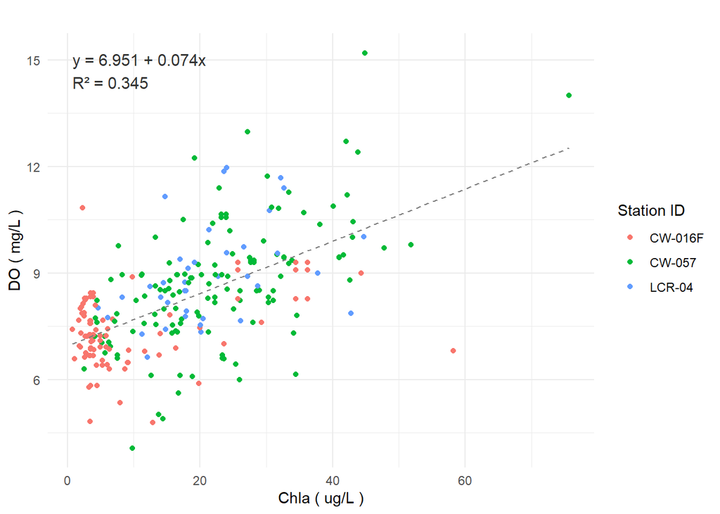

Figure X - DO vs chla at Fishing Creek Reservoir stations.

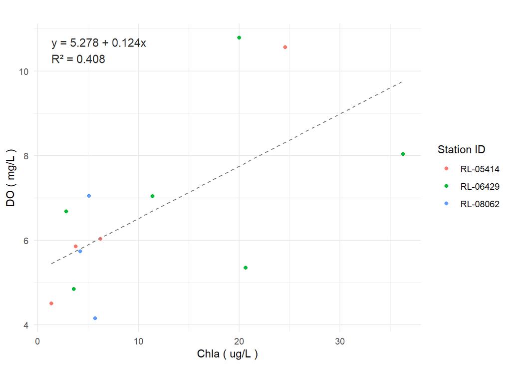

Figure X - DO vs chla at Great Falls Reservoir stations.

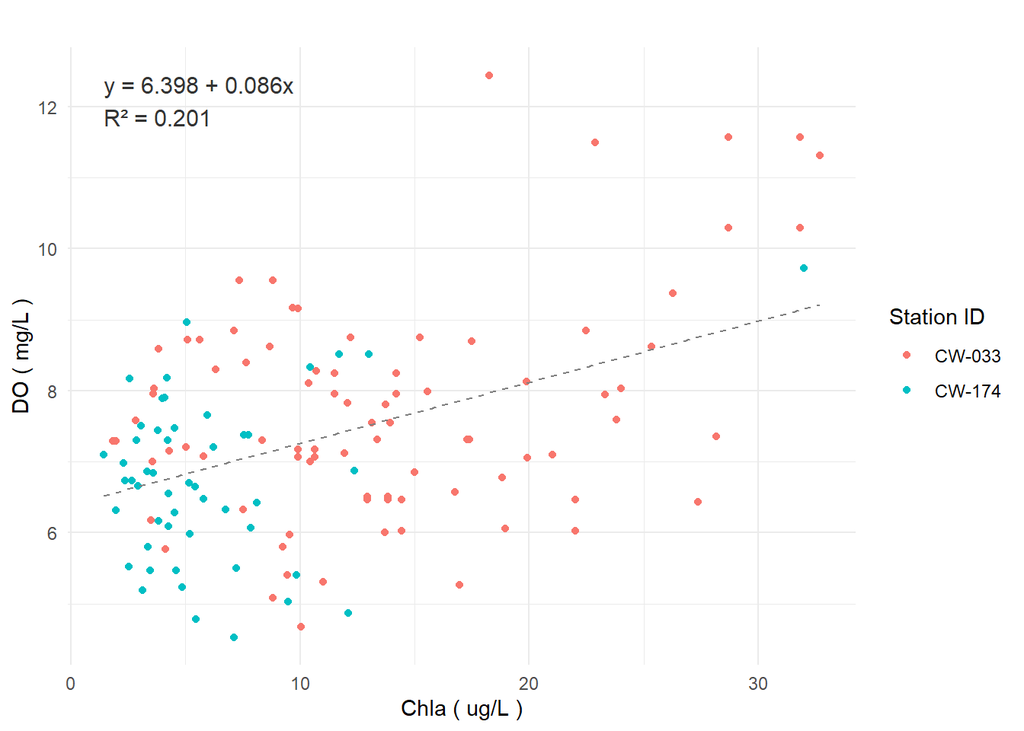

Figure X - DO vs chla at Cedar Creek Reservoir stations.

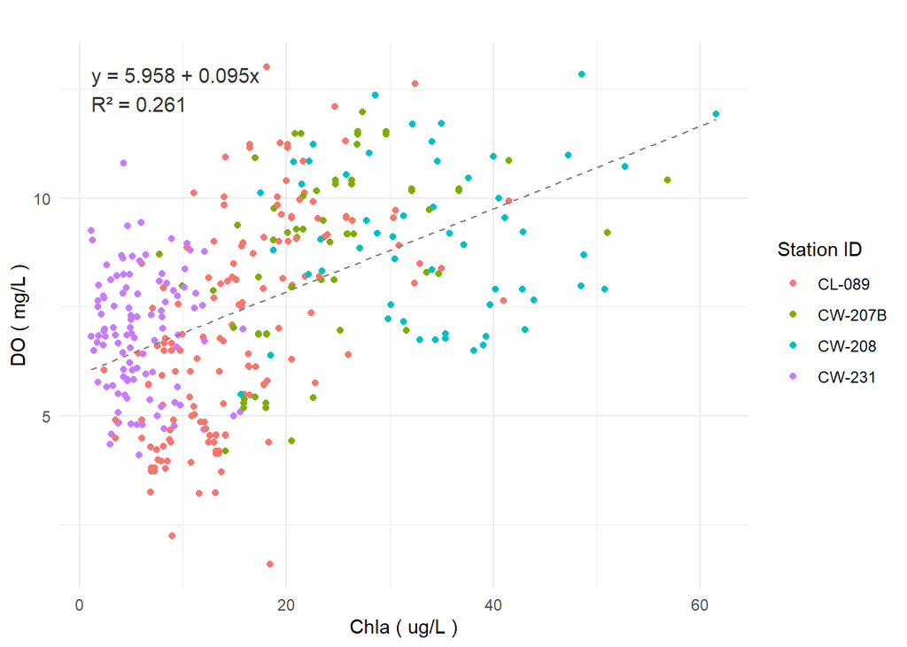

Figure X - DO vs chla at Lake Wateree Reservoir stations.

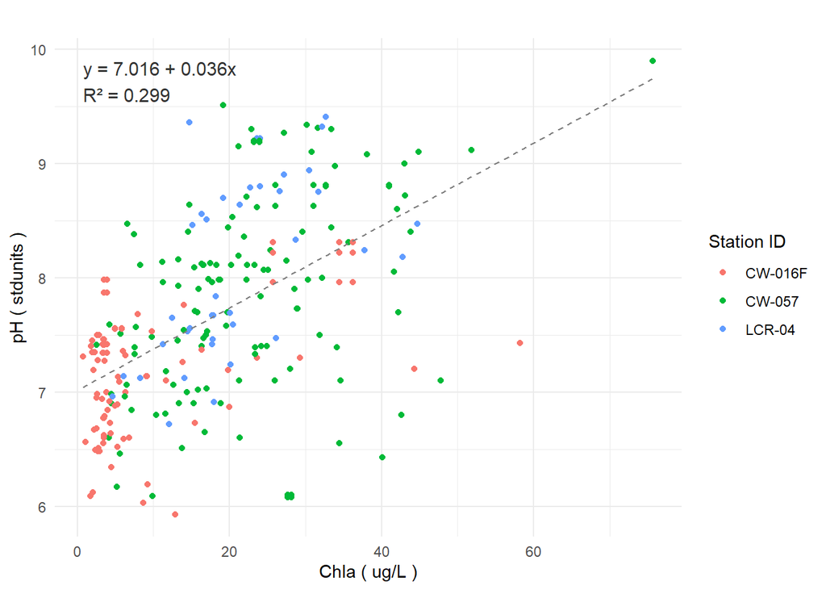

Figure X - pH vs chla at Fishing Creek Reservoir stations.

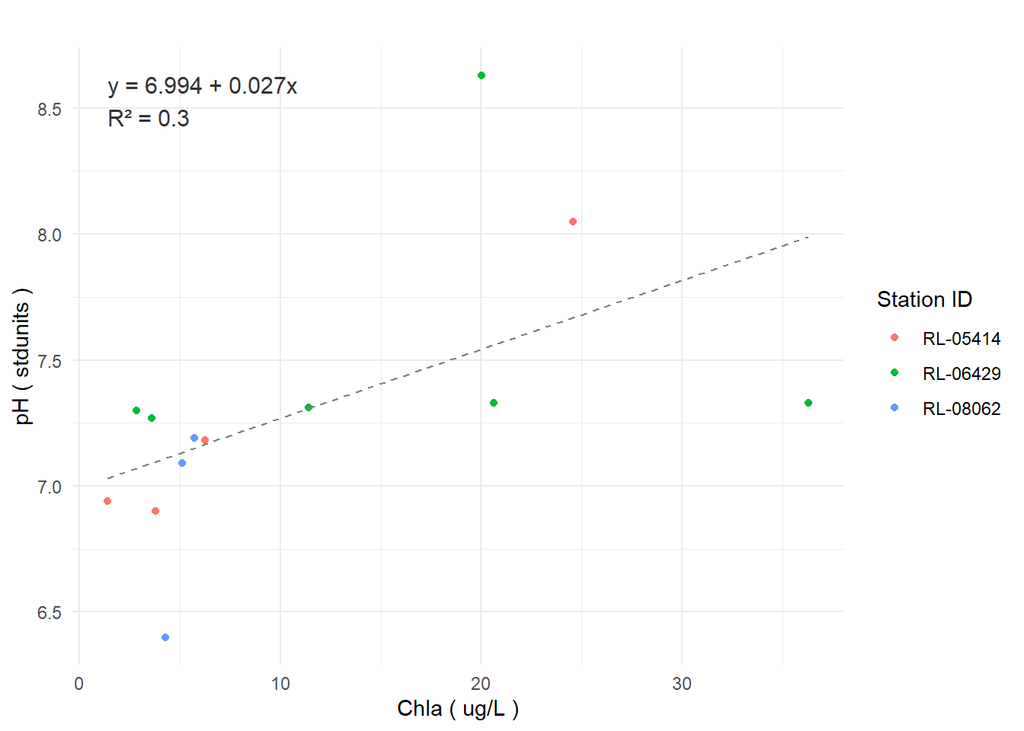

Figure X - pH vs chla at Great Falls Reservoir stations.

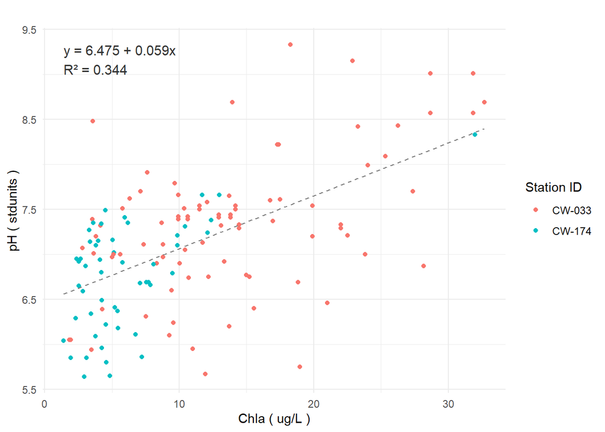

Figure X - pH vs chla at Cedar Creek Reservoir stations.

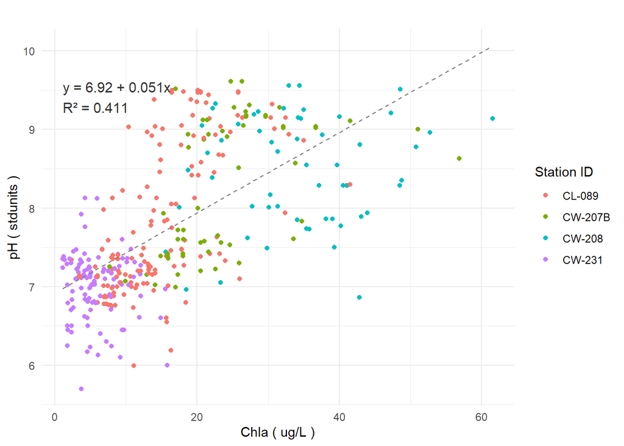

Figure X - pH vs chla at Lake Wateree Reservoir stations.

## Scatterplots of DO vs Depth

Our report might not say anything about DO at depth, but these plots provide some information on that topic.

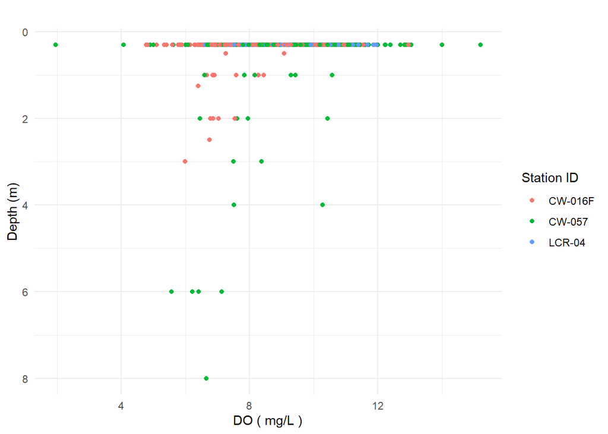

Figure X - DO vs depth at Fishing Creek Reservoir stations.

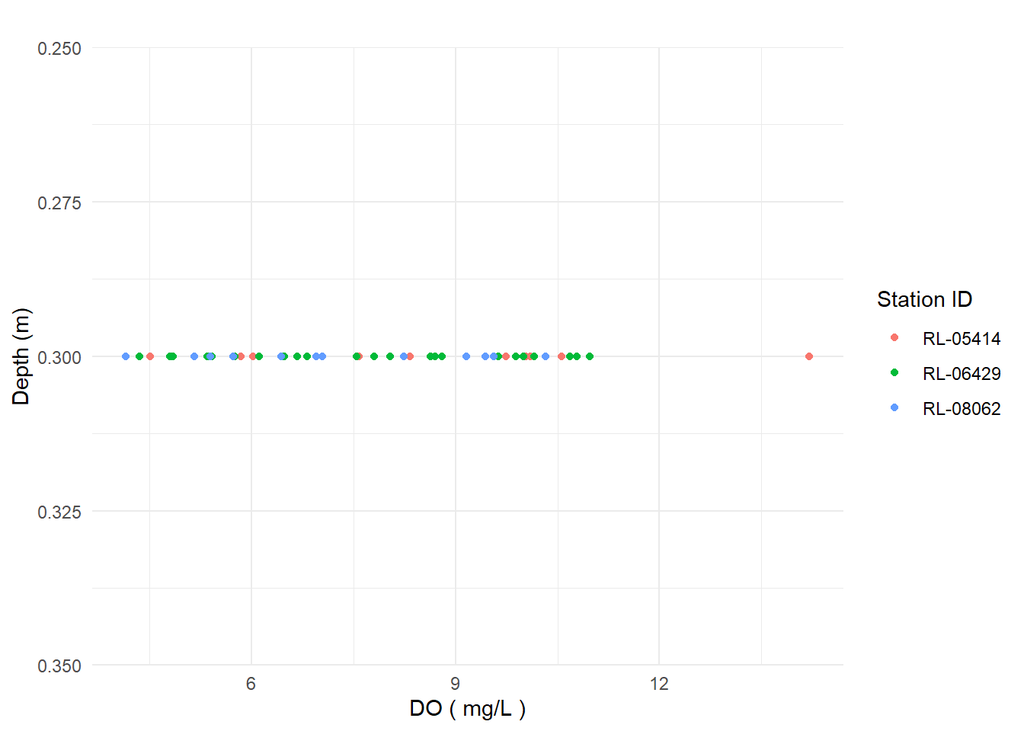

Figure X - DO vs depth at Great Falls Reservoir stations.

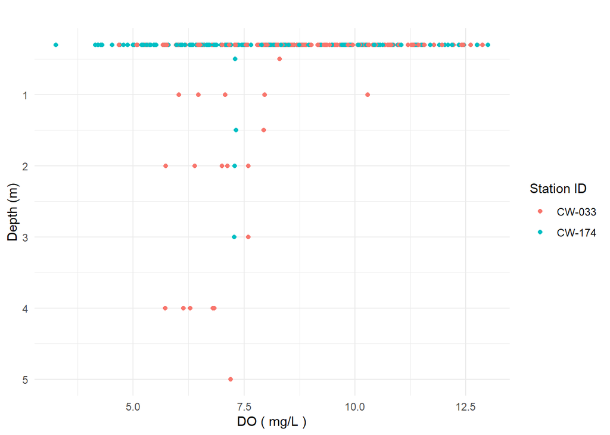

Figure X - DO vs depth at Cedar Creek Reservoir stations.

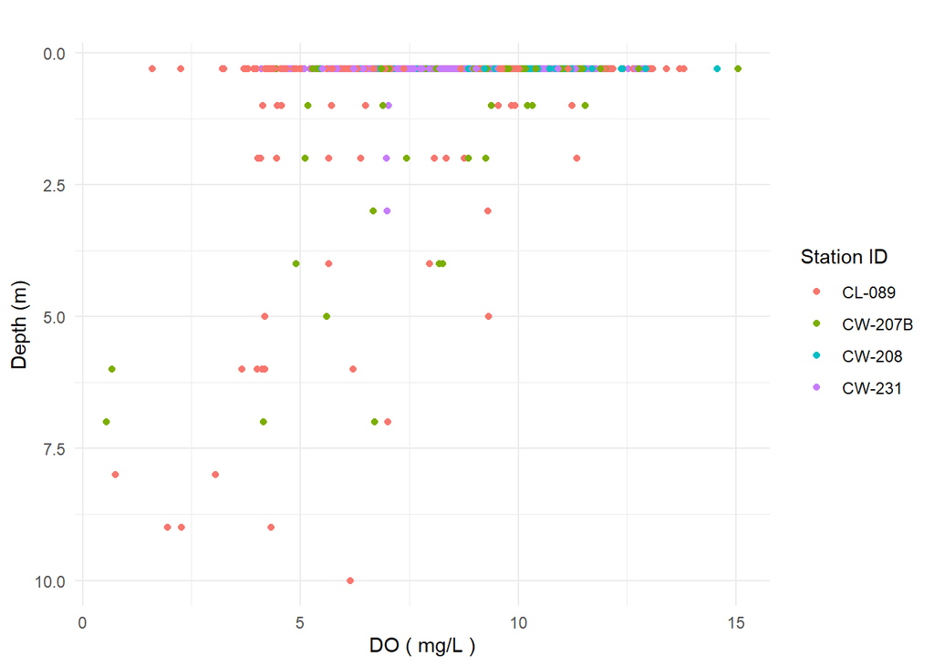

Figure X - DO vs depth at Lake Wateree stations.

## DO and pH Exceedance Tables

These tables are intended to help interpret if the stations/reservoirs have excessive DO (<5) or pH (> 8.5) violations. They only use data <= 1 m depth and stations with at least five data.

| StationID | DO in FISHING CREEK RESERVOIR Threshold = 5 mg/L Count | DO in FISHING CREEK RESERVOIR Threshold = 5 mg/L Below_Threshold_Count | DO in FISHING CREEK RESERVOIR Threshold = 5 mg/L Percentage_Below |
| --- | --- | --- | --- |
| CW-016F | 172 | 2 | 1.2 |
| RL-21226 | 13 | 0 | 0.0 |
| RL-17071 | 12 | 0 | 0.0 |
| RL-21210 | 13 | 0 | 0.0 |
| LCR-01 | 11 | 0 | 0.0 |
| RL-13072 | 12 | 0 | 0.0 |
| RL-01012 | 10 | 0 | 0.0 |
| RL-15023 | 12 | 0 | 0.0 |
| RL-22013 | 12 | 0 | 0.0 |
| LCR-05 | 11 | 0 | 0.0 |
| LCR-04 | 58 | 0 | 0.0 |
| CW-057 | 275 | 3 | 1.1 |

| StationID | DO in GREAT FALLS RESERVOIR Threshold = 5 mg/L Count | DO in GREAT FALLS RESERVOIR Threshold = 5 mg/L Below_Threshold_Count | DO in GREAT FALLS RESERVOIR Threshold = 5 mg/L Percentage_Below |
| --- | --- | --- | --- |
| RL-19258 | 9 | 0 | 0.0 |
| RL-05414 | 11 | 1 | 9.1 |
| RL-03332 | 10 | 0 | 0.0 |
| RL-03458 | 10 | 0 | 0.0 |
| RL-11119 | 6 | 0 | 0.0 |
| RL-08062 | 12 | 1 | 8.3 |
| RL-15108 | 6 | 0 | 0.0 |
| RL-13134 | 12 | 1 | 8.3 |
| RL-03351 | 10 | 1 | 10.0 |
| RL-06429 | 24 | 3 | 12.5 |
| RL-11117 | 12 | 4 | 33.3 |

| StationID | DO in CEDAR CREEK RESERVOIR Threshold = 5 mg/L Count | DO in CEDAR CREEK RESERVOIR Threshold = 5 mg/L Below_Threshold_Count | DO in CEDAR CREEK RESERVOIR Threshold = 5 mg/L Percentage_Below |
| --- | --- | --- | --- |
| RL-04379 | 11 | 0 | 0.0 |
| RL-15104 | 12 | 0 | 0.0 |
| RL-06431 | 12 | 1 | 8.3 |
| RL-10102 | 11 | 0 | 0.0 |
| RL-19254 | 12 | 0 | 0.0 |
| RL-01007 | 24 | 3 | 12.5 |
| CW-174 | 142 | 10 | 7.0 |
| RL-19149 | 23 | 0 | 0.0 |
| CW-175 | 37 | 6 | 16.2 |
| RL-04375 | 11 | 0 | 0.0 |
| RL-07003 | 10 | 0 | 0.0 |
| RL-05391 | 12 | 0 | 0.0 |
| RL-03353 | 11 | 0 | 0.0 |
| RL-14147 | 12 | 1 | 8.3 |
| RL-08046 | 13 | 1 | 7.7 |
| RL-17127 | 12 | 0 | 0.0 |
| RL-21277 | 12 | 0 | 0.0 |
| RL-06443 | 12 | 0 | 0.0 |
| RL-02452 | 10 | 0 | 0.0 |
| RL-22105 | 11 | 0 | 0.0 |
| RL-16115 | 12 | 0 | 0.0 |
| RL-02319 | 21 | 0 | 0.0 |
| RL-01017 | 11 | 1 | 9.1 |
| RL-12125 | 12 | 0 | 0.0 |
| CW-033 | 160 | 1 | 0.6 |
| RL-18146 | 11 | 0 | 0.0 |
| RL-05416 | 12 | 0 | 0.0 |
| RL-09094 | 10 | 0 | 0.0 |

| StationID | DO in LAKE WATEREE Threshold = 5 mg/L Count | DO in LAKE WATEREE Threshold = 5 mg/L Below_Threshold_Count | DO in LAKE WATEREE Threshold = 5 mg/L Percentage_Below |
| --- | --- | --- | --- |
| CW-231 | 228 | 15 | 6.6 |
| RL-15007 | 10 | 0 | 0.0 |
| LCR-02 | 56 | 0 | 0.0 |
| RL-11040 | 12 | 0 | 0.0 |
| RL-19166 | 12 | 0 | 0.0 |
| RL-18083 | 10 | 0 | 0.0 |
| CW-208 | 106 | 0 | 0.0 |
| RL-12056 | 11 | 0 | 0.0 |
| RL-08035 | 12 | 0 | 0.0 |
| LCR-03 | 40 | 0 | 0.0 |
| RL-16039 | 12 | 1 | 8.3 |
| RL-23029 | 6 | 0 | 0.0 |
| RL-13084 | 11 | 0 | 0.0 |
| RL-02314 | 12 | 0 | 0.0 |
| RL-17055 | 11 | 0 | 0.0 |
| CW-207 | 155 | 1 | 0.6 |
| CW-207A | 16 | 0 | 0.0 |
| CW-207B | 69 | 2 | 2.9 |
| RL-21218 | 10 | 0 | 0.0 |
| RL-14155 | 13 | 0 | 0.0 |
| RL-03336 | 12 | 0 | 0.0 |
| RL-09099 | 10 | 0 | 0.0 |
| RL-10008 | 12 | 0 | 0.0 |
| RL-23045 | 6 | 0 | 0.0 |
| RL-01003 | 11 | 0 | 0.0 |
| CW-209 | 48 | 1 | 2.1 |
| RL-20198 | 11 | 0 | 0.0 |
| RL-01033 | 11 | 0 | 0.0 |
| RL-22011 | 11 | 1 | 9.1 |
| CL-089 | 253 | 34 | 13.4 |

| StationID | pH in FISHING CREEK RESERVOIR Threshold = 8.5 stdunits Count | pH in FISHING CREEK RESERVOIR Threshold = 8.5 stdunits Above_Threshold_Count | pH in FISHING CREEK RESERVOIR Threshold = 8.5 stdunits Percentage_Above |
| --- | --- | --- | --- |
| CW-016F | 173 | 0 | 0.0 |
| RL-21226 | 13 | 0 | 0.0 |
| RL-17071 | 12 | 0 | 0.0 |
| RL-21210 | 13 | 0 | 0.0 |
| LCR-01 | 11 | 1 | 9.1 |
| RL-13072 | 12 | 0 | 0.0 |
| RL-01012 | 10 | 1 | 10.0 |
| RL-15023 | 12 | 0 | 0.0 |
| RL-22013 | 12 | 2 | 16.7 |
| LCR-05 | 11 | 6 | 54.5 |
| LCR-04 | 59 | 16 | 27.1 |
| CW-057 | 276 | 33 | 12.0 |

| StationID | pH in GREAT FALLS RESERVOIR Threshold = 8.5 stdunits Count | pH in GREAT FALLS RESERVOIR Threshold = 8.5 stdunits Above_Threshold_Count | pH in GREAT FALLS RESERVOIR Threshold = 8.5 stdunits Percentage_Above |
| --- | --- | --- | --- |
| RL-19258 | 9 | 0 | 0.0 |
| RL-05414 | 11 | 0 | 0.0 |
| RL-03332 | 10 | 0 | 0.0 |
| RL-03458 | 10 | 0 | 0.0 |
| RL-11119 | 6 | 0 | 0.0 |
| RL-08062 | 12 | 0 | 0.0 |
| RL-15108 | 6 | 0 | 0.0 |
| RL-13134 | 12 | 0 | 0.0 |
| RL-03351 | 10 | 0 | 0.0 |
| RL-06429 | 24 | 1 | 4.2 |
| RL-11117 | 12 | 0 | 0.0 |

| StationID | pH in CEDAR CREEK RESERVOIR Threshold = 8.5 stdunits Count | pH in CEDAR CREEK RESERVOIR Threshold = 8.5 stdunits Above_Threshold_Count | pH in CEDAR CREEK RESERVOIR Threshold = 8.5 stdunits Percentage_Above |
| --- | --- | --- | --- |
| RL-04379 | 11 | 0 | 0.0 |
| RL-15104 | 12 | 0 | 0.0 |
| RL-06431 | 12 | 0 | 0.0 |
| RL-10102 | 11 | 0 | 0.0 |
| RL-19254 | 12 | 0 | 0.0 |
| RL-01007 | 24 | 1 | 4.2 |
| CW-174 | 143 | 1 | 0.7 |
| RL-19149 | 24 | 2 | 8.3 |
| CW-175 | 37 | 0 | 0.0 |
| RL-04375 | 11 | 1 | 9.1 |
| RL-07003 | 11 | 3 | 27.3 |
| RL-05391 | 12 | 1 | 8.3 |
| RL-03353 | 11 | 0 | 0.0 |
| RL-14147 | 12 | 1 | 8.3 |
| RL-08046 | 13 | 0 | 0.0 |
| RL-17127 | 12 | 2 | 16.7 |
| RL-21277 | 12 | 1 | 8.3 |
| RL-06443 | 12 | 2 | 16.7 |
| RL-02452 | 10 | 0 | 0.0 |
| RL-22105 | 11 | 1 | 9.1 |
| RL-16115 | 12 | 1 | 8.3 |
| RL-02319 | 22 | 0 | 0.0 |
| RL-01017 | 11 | 0 | 0.0 |
| RL-12125 | 12 | 1 | 8.3 |
| CW-033 | 161 | 11 | 6.8 |
| RL-18146 | 11 | 0 | 0.0 |
| RL-05416 | 12 | 0 | 0.0 |
| RL-09094 | 10 | 0 | 0.0 |

| StationID | pH in LAKE WATEREE Threshold = 8.5 stdunits Count | pH in LAKE WATEREE Threshold = 8.5 stdunits Above_Threshold_Count | pH in LAKE WATEREE Threshold = 8.5 stdunits Percentage_Above |
| --- | --- | --- | --- |
| CW-231 | 229 | 1 | 0.4 |
| RL-15007 | 10 | 0 | 0.0 |
| LCR-02 | 57 | 1 | 1.8 |
| RL-11040 | 12 | 2 | 16.7 |
| RL-19166 | 12 | 5 | 41.7 |
| RL-18083 | 10 | 2 | 20.0 |
| CW-208 | 105 | 39 | 37.1 |
| RL-12056 | 11 | 2 | 18.2 |
| RL-08035 | 12 | 2 | 16.7 |
| LCR-03 | 40 | 12 | 30.0 |
| RL-16039 | 12 | 2 | 16.7 |
| RL-23029 | 6 | 1 | 16.7 |
| RL-13084 | 12 | 4 | 33.3 |
| RL-02314 | 12 | 3 | 25.0 |
| RL-17055 | 10 | 1 | 10.0 |
| CW-207 | 153 | 41 | 26.8 |
| CW-207A | 16 | 13 | 81.2 |
| CW-207B | 69 | 24 | 34.8 |
| RL-21218 | 10 | 4 | 40.0 |
| RL-14155 | 13 | 1 | 7.7 |
| RL-03336 | 12 | 3 | 25.0 |
| RL-09099 | 10 | 2 | 20.0 |
| RL-10008 | 12 | 2 | 16.7 |
| RL-23045 | 6 | 2 | 33.3 |
| RL-01003 | 11 | 0 | 0.0 |
| CW-209 | 47 | 12 | 25.5 |
| RL-20198 | 11 | 1 | 9.1 |
| RL-01033 | 11 | 0 | 0.0 |
| RL-22011 | 12 | 1 | 8.3 |
| CL-089 | 253 | 44 | 17.4 |

## Algal Taxonomy Charts

These charts display both algal count and biovolume by major algal group. Chlorophyll-a (<= 1 m) is displayed for comparison. All data were collected in 2017.

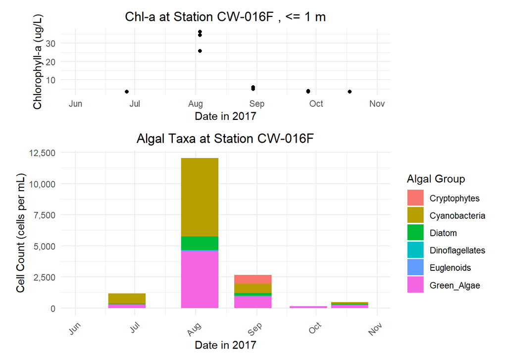

Figure X: CW-016F (Fishing Creek Res.) Chlorophyll-a and Algae Count

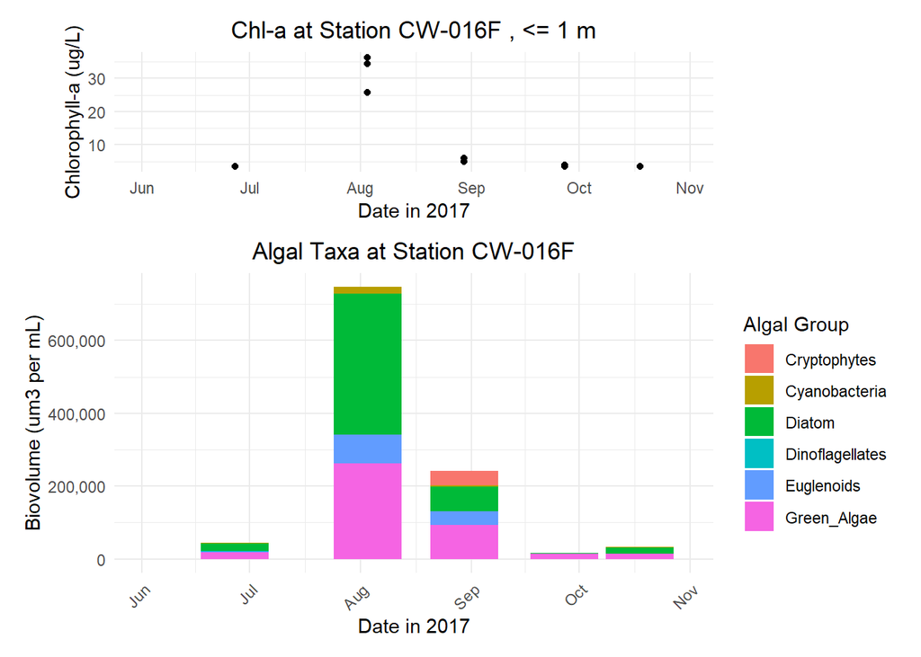

Figure X: CW-016F (Fishing Creek Res.) Chlorophyll-a and Algae Biovolume

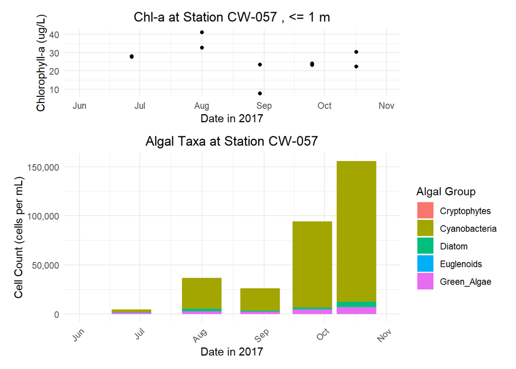

Figure X: CW-057 (Fishing Creek Res.) Chlorophyll-a and Algae Count

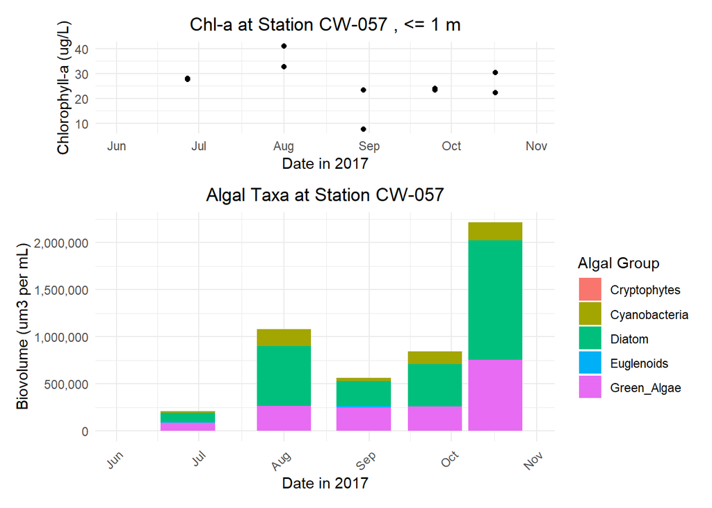

Figure X: CW-057 (Fishing Creek Res.) Chlorophyll-a and Algae Biovolume